## yaml

title: “DS2020 Final Project” author: “Adam Grimm” date: “2024-12-18” output: rmarkdown::github_document

## **Importing The Data**

```r
library(tidyverse)
data_frame <- readr::read_csv("C:\\Users\\grimm\\OneDrive\\Desktop\\Iowa State Fall 2024\\DS2020\\Final Project\\DS2020 Final Project\\PLACES__Local_Data_for_Better_Health__Census_Tract_Data_2024_release_20241214.csv")
head(data_frame)
```

```
## # A tibble: 6 × 24
##    Year StateAbbr StateDesc CountyName       CountyFIPS LocationName DataSource
##   <dbl> <chr>     <chr>     <chr>            <chr>      <chr>        <chr>
## 1  2022 VA        Virginia  Charlottesville  51540      51540000202  BRFSS
## 2  2022 VA        Virginia  Colonial Heights 51570      51570830400  BRFSS
## 3  2022 VA        Virginia  Fairfax          51600      51600300500  BRFSS
## 4  2022 VA        Virginia  Galax            51640      51640070101  BRFSS
## 5  2022 VA        Virginia  Hampton          51650      51650010309  BRFSS
## 6  2022 VA        Virginia  Hampton          51650      51650010312  BRFSS
## # ℹ 17 more variables: Category <chr>, Measure <chr>, Data_Value_Unit <chr>,
## #   Data_Value_Type <chr>, Data_Value <dbl>, Data_Value_Footnote_Symbol <lgl>,
## #   Data_Value_Footnote <lgl>, Low_Confidence_Limit <dbl>,
## #   High_Confidence_Limit <dbl>, TotalPopulation <dbl>, TotalPop18plus <dbl>,
## #   Geolocation <chr>, LocationID <chr>, CategoryID <chr>, MeasureId <chr>,
## #   DataValueTypeID <chr>, Short_Question_Text <chr>
```

**Step: Survey** - Have a look at data types, data frame dimensions, and values

```r
str(data_frame)
```

```
## spc_tbl_ [3,183,048 × 24] (S3: spec_tbl_df/tbl_df/tbl/data.frame)
##  $ Year                      : num [1:3183048] 2022 2022 2022 2022 2022 ...
##  $ StateAbbr                 : chr [1:3183048] "VA" "VA" "VA" "VA" ...
##  $ StateDesc                 : chr [1:3183048] "Virginia" "Virginia" "Virginia" "Virginia" ...
##  $ CountyName                : chr [1:3183048] "Charlottesville" "Colonial Heights" "Fairfax" "Galax" ...
##  $ CountyFIPS                : chr [1:3183048] "51540" "51570" "51600" "51640" ...
##  $ LocationName              : chr [1:3183048] "51540000202" "51570830400" "51600300500" "51640070101" ...
##  $ DataSource                : chr [1:3183048] "BRFSS" "BRFSS" "BRFSS" "BRFSS" ...
##  $ Category                  : chr [1:3183048] "Disability" "Disability" "Health Outcomes" "Health Outcomes" ...
##  $ Measure                   : chr [1:3183048] "Hearing disability among adults" "Hearing disability among adults" "Obesity among adults" "Stroke among adults" ...
##  $ Data_Value_Unit           : chr [1:3183048] "%" "%" "%" "%" ...
##  $ Data_Value_Type           : chr [1:3183048] "Crude prevalence" "Crude prevalence" "Crude prevalence" "Crude prevalence" ...
##  $ Data_Value                : num [1:3183048] 4.6 7.6 30.1 6.2 4 3.6 4.3 39.3 3.6 6 ...
##  $ Data_Value_Footnote_Symbol: logi [1:3183048] NA NA NA NA NA NA ...
##  $ Data_Value_Footnote       : logi [1:3183048] NA NA NA NA NA NA ...
##  $ Low_Confidence_Limit      : num [1:3183048] 4.1 6.8 24.1 5.6 3.7 3.3 3.9 34 3.3 5.5 ...
##  $ High_Confidence_Limit     : num [1:3183048] 5.2 8.5 36.6 6.7 4.3 3.9 4.6 45 3.9 6.6 ...
##  $ TotalPopulation           : num [1:3183048] 5949 2693 3560 4231 4316 ...
##  $ TotalPop18plus            : num [1:3183048] 5241 2053 2955 3382 3424 ...
##  $ Geolocation               : chr [1:3183048] "POINT (-78.4954501 38.0361797)" "POINT (-77.4123511 37.2457225)" "POINT (-77.29894 38.8403654)" "POINT (-80.9188409 36.6588898)" ...
##  $ LocationID                : chr [1:3183048] "51540000202" "51570830400" "51600300500" "51640070101" ...
##  $ CategoryID                : chr [1:3183048] "DISABLT" "DISABLT" "HLTHOUT" "HLTHOUT" ...
##  $ MeasureId                 : chr [1:3183048] "HEARING" "HEARING" "OBESITY" "STROKE" ...
##  $ DataValueTypeID           : chr [1:3183048] "CrdPrv" "CrdPrv" "CrdPrv" "CrdPrv" ...
##  $ Short_Question_Text       : chr [1:3183048] "Hearing Disability" "Hearing Disability" "Obesity" "Stroke" ...
##  - attr(*, "spec")=
##   .. cols(
##   ..   Year = col_double(),
##   ..   StateAbbr = col_character(),
##   ..   StateDesc = col_character(),
##   ..   CountyName = col_character(),
##   ..   CountyFIPS = col_character(),
##   ..   LocationName = col_character(),
##   ..   DataSource = col_character(),
##   ..   Category = col_character(),
##   ..   Measure = col_character(),
##   ..   Data_Value_Unit = col_character(),
##   ..   Data_Value_Type = col_character(),
##   ..   Data_Value = col_double(),
##   ..   Data_Value_Footnote_Symbol = col_logical(),
##   ..   Data_Value_Footnote = col_logical(),
##   ..   Low_Confidence_Limit = col_double(),
##   ..   High_Confidence_Limit = col_double(),
##   ..   TotalPopulation = col_double(),
##   ..   TotalPop18plus = col_double(),
##   ..   Geolocation = col_character(),
##   ..   LocationID = col_character(),
##   ..   CategoryID = col_character(),
##   ..   MeasureId = col_character(),
##   ..   DataValueTypeID = col_character(),
##   ..   Short_Question_Text = col_character()
##   .. )
##  - attr(*, "problems")=<externalptr>
```

```r
dim(data_frame)
```

```
## [1] 3183048      24
```

```r
summary(data_frame)
```

```
##       Year       StateAbbr          StateDesc          CountyName
##  Min.   :2021   Length:3183048     Length:3183048     Length:3183048
##  1st Qu.:2022   Class :character   Class :character   Class :character
##  Median :2022   Mode  :character   Mode  :character   Mode  :character
##  Mean   :2022
##  3rd Qu.:2022
##  Max.   :2022
##   CountyFIPS        LocationName        DataSource          Category
##  Length:3183048     Length:3183048     Length:3183048     Length:3183048
##  Class :character   Class :character   Class :character   Class :character
##  Mode  :character   Mode  :character   Mode  :character   Mode  :character
##
##
##
##    Measure          Data_Value_Unit    Data_Value_Type      Data_Value
##  Length:3183048     Length:3183048     Length:3183048     Min.   : 0.20
##  Class :character   Class :character   Class :character   1st Qu.: 9.10
##  Mode  :character   Mode  :character   Mode  :character   Median :17.00
##                                                           Mean   :25.69
##                                                           3rd Qu.:33.80
##                                                           Max.   :98.00
##  Data_Value_Footnote_Symbol Data_Value_Footnote Low_Confidence_Limit
##  Mode:logical               Mode:logical        Min.   : 0.20
##  NA's:3183048               NA's:3183048        1st Qu.: 8.00
##                                                 Median :15.00
##                                                 Mean   :23.46
##                                                 3rd Qu.:29.90
##                                                 Max.   :97.60
##  High_Confidence_Limit TotalPopulation TotalPop18plus  Geolocation
##  Min.   : 0.30         Min.   :   54   Min.   :   50   Length:3183048
##  1st Qu.:10.20         1st Qu.: 2774   1st Qu.: 2185   Class :character
##  Median :19.20         Median : 3787   Median : 2958   Mode  :character
##  Mean   :27.98         Mean   : 3972   Mean   : 3094
##  3rd Qu.:37.70         3rd Qu.: 4950   3rd Qu.: 3845
##  Max.   :98.30         Max.   :37892   Max.   :31280
##   LocationID         CategoryID         MeasureId         DataValueTypeID
##  Length:3183048     Length:3183048     Length:3183048     Length:3183048
##  Class :character   Class :character   Class :character   Class :character
##  Mode  :character   Mode  :character   Mode  :character   Mode  :character
##
##
##
##  Short_Question_Text
##  Length:3183048
##  Class :character
##  Mode  :character
##
##
##
```

```r
sapply(data_frame, class)
```

```
##                       Year                  StateAbbr
##                  "numeric"                "character"
##                  StateDesc                 CountyName
##                "character"                "character"
##                 CountyFIPS               LocationName
##                "character"                "character"
##                 DataSource                   Category
##                "character"                "character"
##                    Measure            Data_Value_Unit
##                "character"                "character"
##            Data_Value_Type                 Data_Value
##                "character"                  "numeric"
## Data_Value_Footnote_Symbol        Data_Value_Footnote
##                  "logical"                  "logical"
##       Low_Confidence_Limit      High_Confidence_Limit
##                  "numeric"                  "numeric"
##            TotalPopulation             TotalPop18plus
##                  "numeric"                  "numeric"
##                Geolocation                 LocationID
##                "character"                "character"
##                 CategoryID                  MeasureId
##                "character"                "character"
##            DataValueTypeID        Short_Question_Text
##                "character"                "character"
```

```r
colnames(data_frame)
```

```
##  [1] "Year"                       "StateAbbr"
##  [3] "StateDesc"                  "CountyName"
##  [5] "CountyFIPS"                 "LocationName"
##  [7] "DataSource"                 "Category"
##  [9] "Measure"                    "Data_Value_Unit"
## [11] "Data_Value_Type"            "Data_Value"
## [13] "Data_Value_Footnote_Symbol" "Data_Value_Footnote"
## [15] "Low_Confidence_Limit"       "High_Confidence_Limit"
## [17] "TotalPopulation"            "TotalPop18plus"
## [19] "Geolocation"                "LocationID"
## [21] "CategoryID"                 "MeasureId"
## [23] "DataValueTypeID"            "Short_Question_Text"
```

Note 1: Data frame measurement 3,183,048 rows, 24 columns

Note 2: Numeric, Character, Logical values present

```r
length(unique(data_frame$Year))
```

```
## [1] 2
```

```r
unique(data_frame$Year)
```

```
## [1] 2022 2021
```

```r
length(unique(data_frame$StateAbbr))
```

```
## [1] 51
```

```r
unique(data_frame$StateAbbr)
```

```
##  [1] "VA" "WA" "WV" "WI" "WY" "NY" "NC" "ND" "OH" "OK" "OR" "PA" "RI" "SC" "TN"
## [16] "TX" "UT" "VT" "SD" "IA" "IL" "IN" "KS" "KY" "LA" "ME" "MD" "MA" "MI" "MN"
## [31] "MS" "MO" "MT" "NE" "NV" "NH" "NJ" "NM" "AL" "AK" "AZ" "AR" "CA" "CO" "CT"
## [46] "DE" "FL" "GA" "HI" "ID" "DC"
```

```r
length(unique(data_frame$Category))
```

```
## [1] 6
```

```r
unique(data_frame$Category)
```

```
## [1] "Disability"                  "Health Outcomes"
## [3] "Prevention"                  "Health Risk Behaviors"
## [5] "Health Status"               "Health-Related Social Needs"
```

```r
length(unique(data_frame$Measure))
```

```
## [1] 40
```

```r
unique(data_frame$Measure)
```

```
##  [1] "Hearing disability among adults"
##  [2] "Obesity among adults"
##  [3] "Stroke among adults"
##  [4] "Depression among adults"
##  [5] "Any disability among adults"
##  [6] "Arthritis among adults"
##  [7] "Diagnosed diabetes among adults"
##  [8] "Current asthma among adults"
##  [9] "Cognitive disability among adults"
## [10] "Cholesterol screening among adults"
## [11] "Current lack of health insurance among adults aged 18-64 years"
## [12] "Visited dentist or dental clinic in the past year among adults"
## [13] "All teeth lost among adults aged >=65 years"
## [14] "No leisure-time physical activity among adults"
## [15] "Fair or poor self-rated health status among adults"
```

[output cut: 25 more lines]

```r
length(unique(data_frame$Data_Value_Unit))
```

```
## [1] 1
```

```r
unique(data_frame$Data_Value_Unit)
```

```
## [1] "%"
```

```r
length(unique(data_frame$Data_Value_Type))
```

```
## [1] 1
```

```r
unique(data_frame$Data_Value_Type)
```

```
## [1] "Crude prevalence"
```

Note 2: The Data is for all 51 states, but no territories.

Note 3: There are six values for the “Category” column, Disability, Health Outcomes, Prevention, Health Risk Behaviors, Health Status, Health-Related Social Needs

Note 4: There are 40 values for the “Measures” column. There are likely multiple for each category, but I’m not going to check that here.

Note 5: There is only 1 value for Data_Value_Unit %. This percentile all units for for percentile

# Cleaning

**Step : Cleaning** - Looking for Null Values

```r
#Count the number of null and non null for each column
null_counts <- sapply(data_frame, function(x) sum(is.na(x)))
non_null_counts <- sapply(data_frame, function(x) sum(!is.na(x)))

#Create small table to see the number of null non-null for each column
null_summary <- data.frame(
  Column = names(data_frame),
  Null_Count = null_counts,
  Non_Null_Count = non_null_counts
)
#display table
null_summary
```

```
##                                                Column Null_Count Non_Null_Count
## Year                                             Year          0        3183048
## StateAbbr                                   StateAbbr          0        3183048
## StateDesc                                   StateDesc          0        3183048
## CountyName                                 CountyName          0        3183048
## CountyFIPS                                 CountyFIPS          0        3183048
## LocationName                             LocationName          0        3183048
## DataSource                                 DataSource          0        3183048
## Category                                     Category          0        3183048
## Measure                                       Measure          0        3183048
## Data_Value_Unit                       Data_Value_Unit          0        3183048
## Data_Value_Type                       Data_Value_Type          0        3183048
## Data_Value                                 Data_Value          0        3183048
## Data_Value_Footnote_Symbol Data_Value_Footnote_Symbol    3183048              0
## Data_Value_Footnote               Data_Value_Footnote    3183048              0
## Low_Confidence_Limit             Low_Confidence_Limit          0        3183048
## High_Confidence_Limit           High_Confidence_Limit          0        3183048
## TotalPopulation                       TotalPopulation          0        3183048
## TotalPop18plus                         TotalPop18plus          0        3183048
## Geolocation                               Geolocation          0        3183048
## LocationID                                 LocationID          0        3183048
## CategoryID                                 CategoryID          0        3183048
## MeasureId                                   MeasureId          0        3183048
## DataValueTypeID                       DataValueTypeID          0        3183048
## Short_Question_Text               Short_Question_Text          0        3183048
```

Note 1: Data_Value_Footnote_Symbol and Data_Value_Footnote both have 3,183,048 null counts which is the same as the number of rows. Both of these rows can be eliminated

**Step: Cleaning -** Remove Unneeded columns Data_Value_Footnote_Symbol and Data_Value_Footnote

```r
data_frame <- data_frame[, !(colnames(data_frame) %in% c("Data_Value_Footnote", "Data_Value_Footnote_Symbol"))]

colnames(data_frame)
```

```
##  [1] "Year"                  "StateAbbr"             "StateDesc"
##  [4] "CountyName"            "CountyFIPS"            "LocationName"
##  [7] "DataSource"            "Category"              "Measure"
## [10] "Data_Value_Unit"       "Data_Value_Type"       "Data_Value"
## [13] "Low_Confidence_Limit"  "High_Confidence_Limit" "TotalPopulation"
## [16] "TotalPop18plus"        "Geolocation"           "LocationID"
## [19] "CategoryID"            "MeasureId"             "DataValueTypeID"
## [22] "Short_Question_Text"
```

```r
head(data_frame)
```

```
## # A tibble: 6 × 22
##    Year StateAbbr StateDesc CountyName       CountyFIPS LocationName DataSource
##   <dbl> <chr>     <chr>     <chr>            <chr>      <chr>        <chr>
## 1  2022 VA        Virginia  Charlottesville  51540      51540000202  BRFSS
## 2  2022 VA        Virginia  Colonial Heights 51570      51570830400  BRFSS
## 3  2022 VA        Virginia  Fairfax          51600      51600300500  BRFSS
## 4  2022 VA        Virginia  Galax            51640      51640070101  BRFSS
## 5  2022 VA        Virginia  Hampton          51650      51650010309  BRFSS
## 6  2022 VA        Virginia  Hampton          51650      51650010312  BRFSS
## # ℹ 15 more variables: Category <chr>, Measure <chr>, Data_Value_Unit <chr>,
## #   Data_Value_Type <chr>, Data_Value <dbl>, Low_Confidence_Limit <dbl>,
## #   High_Confidence_Limit <dbl>, TotalPopulation <dbl>, TotalPop18plus <dbl>,
## #   Geolocation <chr>, LocationID <chr>, CategoryID <chr>, MeasureId <chr>,
## #   DataValueTypeID <chr>, Short_Question_Text <chr>
```

Note 1: Dataframe is now 3183048 by 22 now

# Data Manipulation/Organization

**Step: Data Manipulation** -Find National, State, County Average,Median and Mode for each Measure So I can compare each state and county against the National Average.

```r
library(dplyr)

get_mode <- function(x) {
  uniq_x <- unique(na.omit(x))
  uniq_x[which.max(tabulate(match(x, uniq_x)))]
}


national_stats <- data_frame %>%
  group_by(Year, Measure) %>%
  summarise(
    National_Average = mean(Data_Value, na.rm = TRUE),
    National_Median = median(Data_Value, na.rm = TRUE),
    National_Mode = get_mode(Data_Value)
  )
state_stats <- data_frame %>%
  group_by(Year, StateAbbr, Measure) %>%
  summarise(
    State_Average = mean(Data_Value, na.rm = TRUE),
    State_Median = median(Data_Value, na.rm = TRUE),
    State_Mode = get_mode(Data_Value)
  )
county_stats <- data_frame %>%
  group_by(Year, StateAbbr, CountyName, Measure) %>%
  summarise(
    County_Average = mean(Data_Value, na.rm = TRUE),
    County_Median = median(Data_Value, na.rm = TRUE),
    County_Mode = get_mode(Data_Value)
  )
data_frame <- left_join(data_frame, national_stats, by = c("Year", "Measure"))

# Join State stats
data_frame <- left_join(data_frame, state_stats, by = c("Year", "StateAbbr", "Measure"))

# Join County stats
data_frame <- left_join(data_frame, county_stats, by = c("Year", "StateAbbr", "CountyName", "Measure"))

# View the updated data frame
print(head(data_frame))
```

```
## # A tibble: 6 × 31
##    Year StateAbbr StateDesc CountyName       CountyFIPS LocationName DataSource
##   <dbl> <chr>     <chr>     <chr>            <chr>      <chr>        <chr>
## 1  2022 VA        Virginia  Charlottesville  51540      51540000202  BRFSS
## 2  2022 VA        Virginia  Colonial Heights 51570      51570830400  BRFSS
## 3  2022 VA        Virginia  Fairfax          51600      51600300500  BRFSS
## 4  2022 VA        Virginia  Galax            51640      51640070101  BRFSS
## 5  2022 VA        Virginia  Hampton          51650      51650010309  BRFSS
## 6  2022 VA        Virginia  Hampton          51650      51650010312  BRFSS
## # ℹ 24 more variables: Category <chr>, Measure <chr>, Data_Value_Unit <chr>,
## #   Data_Value_Type <chr>, Data_Value <dbl>, Low_Confidence_Limit <dbl>,
## #   High_Confidence_Limit <dbl>, TotalPopulation <dbl>, TotalPop18plus <dbl>,
## #   Geolocation <chr>, LocationID <chr>, CategoryID <chr>, MeasureId <chr>,
## #   DataValueTypeID <chr>, Short_Question_Text <chr>, National_Average <dbl>,
## #   National_Median <dbl>, National_Mode <dbl>, State_Average <dbl>,
## #   State_Median <dbl>, State_Mode <dbl>, County_Average <dbl>, …
```

**Step: Data Manipulation** - Comparing national averages to state and county and creating new columns

```r
data_frame <- data_frame %>%
  mutate(
    # Differences between State and National statistics
    State_National_Avg_Diff = State_Average - National_Average,
    State_National_Med_Diff = State_Median - National_Median,
    State_National_Mode_Diff = State_Mode - National_Mode,

    # Differences between County and National statistics
    County_National_Avg_Diff = County_Average - National_Average,
    County_National_Med_Diff = County_Median - National_Median,
    County_National_Mode_Diff = County_Mode - National_Mode,

    # Differences between County and State statistics
    County_State_Avg_Diff = County_Average - State_Average,
    County_State_Med_Diff = County_Median - State_Median,
    County_State_Mode_Diff = County_Mode - State_Mode
  )

# View updated data frame
print(head(data_frame))
```

```
## # A tibble: 6 × 40
##    Year StateAbbr StateDesc CountyName       CountyFIPS LocationName DataSource
##   <dbl> <chr>     <chr>     <chr>            <chr>      <chr>        <chr>
## 1  2022 VA        Virginia  Charlottesville  51540      51540000202  BRFSS
## 2  2022 VA        Virginia  Colonial Heights 51570      51570830400  BRFSS
## 3  2022 VA        Virginia  Fairfax          51600      51600300500  BRFSS
## 4  2022 VA        Virginia  Galax            51640      51640070101  BRFSS
## 5  2022 VA        Virginia  Hampton          51650      51650010309  BRFSS
## 6  2022 VA        Virginia  Hampton          51650      51650010312  BRFSS
## # ℹ 33 more variables: Category <chr>, Measure <chr>, Data_Value_Unit <chr>,
## #   Data_Value_Type <chr>, Data_Value <dbl>, Low_Confidence_Limit <dbl>,
## #   High_Confidence_Limit <dbl>, TotalPopulation <dbl>, TotalPop18plus <dbl>,
## #   Geolocation <chr>, LocationID <chr>, CategoryID <chr>, MeasureId <chr>,
## #   DataValueTypeID <chr>, Short_Question_Text <chr>, National_Average <dbl>,
## #   National_Median <dbl>, National_Mode <dbl>, State_Average <dbl>,
## #   State_Median <dbl>, State_Mode <dbl>, County_Average <dbl>, …
```

**Step: Data Manipulation** - Distinguish “Measures” with positive vs negative outcomes.

```r
# Create list of positive and negative measures
positive_measures <- c(
  "Cholesterol screening among adults",
  "Visited dentist or dental clinic in the past year among adults",
  "Visits to doctor for routine checkup within the past year among adults",
  "Colorectal cancer screening among adults aged 45–75 years",
  "Mammography use among women aged 50-74 years"
)

# Add Category_Type column
data_frame <- data_frame %>%
  mutate(
    Category_Type = ifelse(Measure %in% positive_measures, "Positive", "Negative")
  )

# Check the updated data
head(data_frame)
```

```
## # A tibble: 6 × 41
##    Year StateAbbr StateDesc CountyName       CountyFIPS LocationName DataSource
##   <dbl> <chr>     <chr>     <chr>            <chr>      <chr>        <chr>
## 1  2022 VA        Virginia  Charlottesville  51540      51540000202  BRFSS
## 2  2022 VA        Virginia  Colonial Heights 51570      51570830400  BRFSS
## 3  2022 VA        Virginia  Fairfax          51600      51600300500  BRFSS
## 4  2022 VA        Virginia  Galax            51640      51640070101  BRFSS
## 5  2022 VA        Virginia  Hampton          51650      51650010309  BRFSS
## 6  2022 VA        Virginia  Hampton          51650      51650010312  BRFSS
## # ℹ 34 more variables: Category <chr>, Measure <chr>, Data_Value_Unit <chr>,
## #   Data_Value_Type <chr>, Data_Value <dbl>, Low_Confidence_Limit <dbl>,
## #   High_Confidence_Limit <dbl>, TotalPopulation <dbl>, TotalPop18plus <dbl>,
## #   Geolocation <chr>, LocationID <chr>, CategoryID <chr>, MeasureId <chr>,
## #   DataValueTypeID <chr>, Short_Question_Text <chr>, National_Average <dbl>,
## #   National_Median <dbl>, National_Mode <dbl>, State_Average <dbl>,
## #   State_Median <dbl>, State_Mode <dbl>, County_Average <dbl>, …
```

# **Data Exploration**

**Step: Data Exploration** - Reverse rank count for positive measures

```r
data_frame <- data_frame %>%
  group_by(Year, Measure) %>%
  mutate(
    # Adjust State Rank: Reverse for positive measures
    State_Rank = ifelse(Category_Type == "Positive",
                        dense_rank(desc(State_National_Avg_Diff)),  # Reverse rank for Positive
                        dense_rank(State_National_Avg_Diff))        # Normal rank for Negative
  ) %>%
  group_by(Year, StateAbbr, Measure) %>%
  mutate(
    # Adjust County Rank: Reverse for positive measures
    County_Rank = ifelse(Category_Type == "Positive",
                         dense_rank(desc(County_State_Avg_Diff)),   # Reverse rank for Positive
                         dense_rank(County_State_Avg_Diff))         # Normal rank for Negative
  ) %>%
  ungroup() # Remove grouping to avoid conflicts later

# View the updated data frame
print(head(data_frame))
```

```
## # A tibble: 6 × 43
##    Year StateAbbr StateDesc CountyName       CountyFIPS LocationName DataSource
##   <dbl> <chr>     <chr>     <chr>            <chr>      <chr>        <chr>
## 1  2022 VA        Virginia  Charlottesville  51540      51540000202  BRFSS
## 2  2022 VA        Virginia  Colonial Heights 51570      51570830400  BRFSS
## 3  2022 VA        Virginia  Fairfax          51600      51600300500  BRFSS
## 4  2022 VA        Virginia  Galax            51640      51640070101  BRFSS
## 5  2022 VA        Virginia  Hampton          51650      51650010309  BRFSS
## 6  2022 VA        Virginia  Hampton          51650      51650010312  BRFSS
## # ℹ 36 more variables: Category <chr>, Measure <chr>, Data_Value_Unit <chr>,
## #   Data_Value_Type <chr>, Data_Value <dbl>, Low_Confidence_Limit <dbl>,
## #   High_Confidence_Limit <dbl>, TotalPopulation <dbl>, TotalPop18plus <dbl>,
## #   Geolocation <chr>, LocationID <chr>, CategoryID <chr>, MeasureId <chr>,
## #   DataValueTypeID <chr>, Short_Question_Text <chr>, National_Average <dbl>,
## #   National_Median <dbl>, National_Mode <dbl>, State_Average <dbl>,
## #   State_Median <dbl>, State_Mode <dbl>, County_Average <dbl>, …
```

**Step: Data Exploration** - Ranking each state based on how it compares to national average for each “Measure”, and averaging all of each state’s “Measures” together and applying overall rank. For instances of “Ties that occur in the Average_State_Rank the state with a higher percentage of counties above the national average wins the tie.

```r
county_percentage <- data_frame %>%
  group_by(Year, StateAbbr) %>%
  summarise(
    Total_Counties = n(),
    Counties_Above_National = sum(County_National_Avg_Diff > 0, na.rm = TRUE),
    Percentage_Above_National = (Counties_Above_National / Total_Counties) * 100
  )
state_yearly_ranks <- data_frame %>%
  group_by(Year, StateAbbr) %>%
  summarise(
    Average_State_Rank = mean(State_Rank, na.rm = TRUE) # Average rank per state and year
  ) %>%
  left_join(county_percentage, by = c("Year", "StateAbbr")) %>% # Join with percentages
  group_by(Year) %>%
  arrange(Year, Average_State_Rank, desc(Percentage_Above_National)) %>% # Sort by rank and tie-breaker
  mutate(
    Overall_Rank = row_number() # Assign unique ranks based on sorted order
  ) %>%
  ungroup()
print(state_yearly_ranks)
```

```
## # A tibble: 101 × 7
##     Year StateAbbr Average_State_Rank Total_Counties Counties_Above_National
##    <dbl> <chr>                  <dbl>          <int>                   <int>
##  1  2021 DC                       3.5            824                     206
##  2  2021 CO                       9.5           5748                     688
##  3  2021 MA                      10.5           6388                    3000
##  4  2021 CA                      12.8          36280                   12026
##  5  2021 UT                      13.2           2840                     104
##  6  2021 MN                      14.2           6000                    1461
##  7  2021 WA                      14.2           7080                     831
##  8  2021 VT                      14.8            768                     212
##  9  2021 CT                      15.2           3504                    1677
## 10  2021 OR                      15.8           3972                     658
## # ℹ 91 more rows
## # ℹ 2 more variables: Percentage_Above_National <dbl>, Overall_Rank <int>
```

**Step: Data Exploration -** Separated original graph into increasing rank, decreasing rank, and no movement

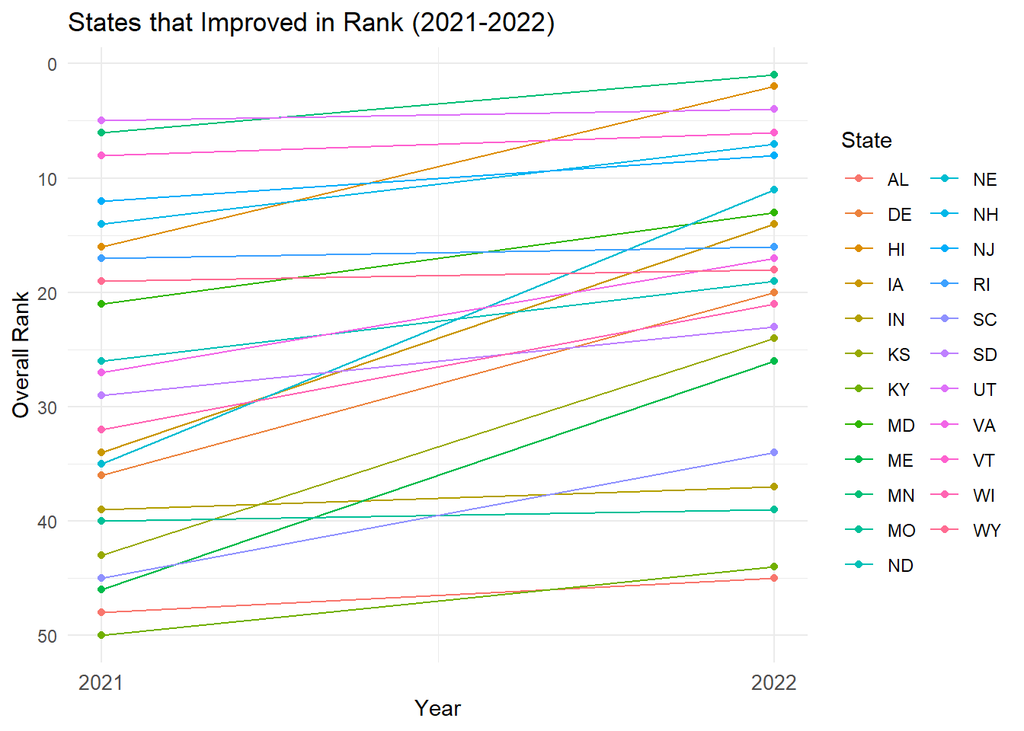

```r
library(ggplot2)
library(dplyr)


rank_movement <- state_yearly_ranks %>%
  filter(Year %in% c(2021, 2022)) %>% # Focus only on 2021 and 2022
  select(StateAbbr, Year, Overall_Rank) %>%
  pivot_wider(names_from = Year, values_from = Overall_Rank, names_prefix = "Rank_") %>%
  mutate(
    Rank_Change = Rank_2021 - Rank_2022, # Positive = moved up, Negative = moved down
    Movement_Category = case_when(
      Rank_Change > 0 ~ "Up",       # Improved in rank
      Rank_Change < 0 ~ "Down",     # Worsened in rank
      Rank_Change == 0 ~ "Same"     # Stayed the same
    )
  )


state_yearly_ranks_with_movement <- state_yearly_ranks %>%
  left_join(rank_movement %>% select(StateAbbr, Movement_Category), by = "StateAbbr")

up_states <- state_yearly_ranks_with_movement %>%
  filter(Movement_Category == "Up")


ggplot(up_states, aes(x = Year, y = Overall_Rank, group = StateAbbr, color = StateAbbr)) +
  geom_line() +
  geom_point() +
  scale_x_continuous(breaks = c(2021, 2022), labels = c("2021", "2022")) +
  scale_y_reverse() + # Reverse y-axis so rank 1 is at the top
  labs(
    title = "States that Improved in Rank (2021-2022)",
    x = "Year",
    y = "Overall Rank",
    color = "State"
  ) +
  theme_minimal() +
  theme(
    axis.text.x = element_text(size = 10),
    legend.position = "right"
  )
```

Notes: For states that moving up in rank, it seems like there is about and equal amount of state jumping several spots and others gradually increasing.

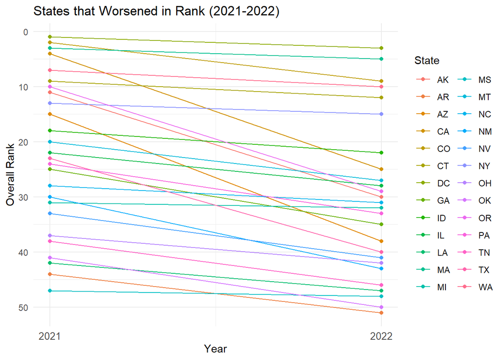

```r
# Filter for "Down" states
down_states <- state_yearly_ranks_with_movement %>%
  filter(Movement_Category == "Down")

# Plot for States that Worsened in Rank
ggplot(down_states, aes(x = Year, y = Overall_Rank, group = StateAbbr, color = StateAbbr)) +
  geom_line() +
  geom_point() +
  scale_x_continuous(breaks = c(2021, 2022), labels = c("2021", "2022")) +
  scale_y_reverse() +
  labs(
    title = "States that Worsened in Rank (2021-2022)",
    x = "Year",
    y = "Overall Rank",
    color = "State"
  ) +
  theme_minimal() +
  theme(
    axis.text.x = element_text(size = 10),
    legend.position = "right"
  )
```

Notes: It seems like about ten states had significant health rank changes from 2021 to 2022

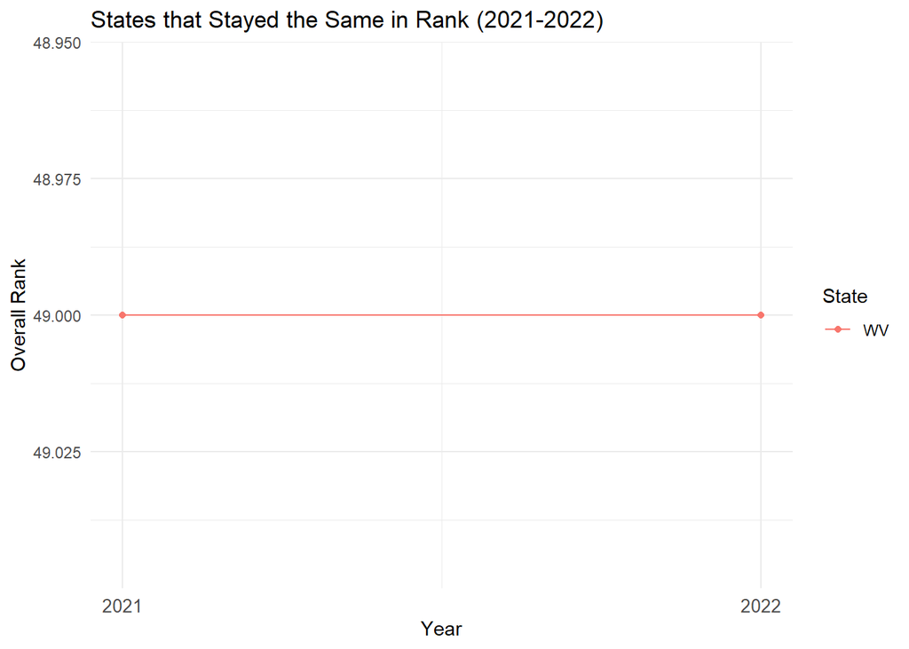

```r
same_states <- state_yearly_ranks_with_movement %>%
  filter(Movement_Category == "Same")

# Plot for States that Stayed the Same
ggplot(same_states, aes(x = Year, y = Overall_Rank, group = StateAbbr, color = StateAbbr)) +
  geom_line() +
  geom_point() +
  scale_x_continuous(breaks = c(2021, 2022), labels = c("2021", "2022")) +
  scale_y_reverse() +
  labs(
    title = "States that Stayed the Same in Rank (2021-2022)",
    x = "Year",
    y = "Overall Rank",
    color = "State"
  ) +
  theme_minimal() +
  theme(
    axis.text.x = element_text(size = 10),
    legend.position = "right"
  )
```

Note: Only WV maintained its position.

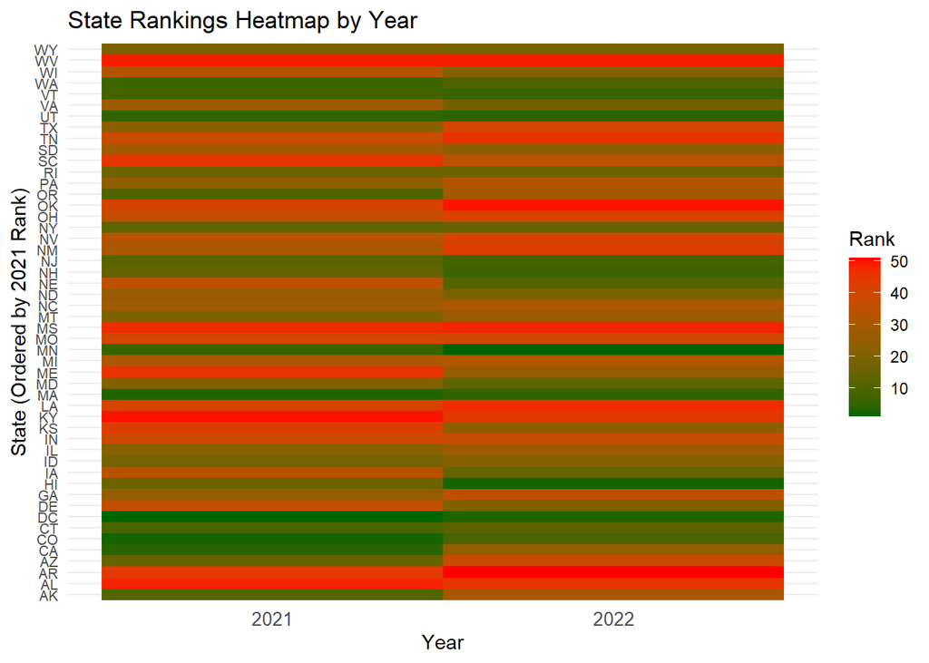

```r
library(ggplot2)
library(dplyr)

filtered_state_ranks <- state_yearly_ranks %>%
  filter(!is.na(StateAbbr) & StateAbbr != "FL")

# Step 1: Reorder StateAbbr based on 2021 ranks
state_order <- state_yearly_ranks %>%
  filter(Year == 2021) %>%
  arrange(Overall_Rank) %>% # Arrange by rank so top-ranked states are first
  pull(StateAbbr)           # Extract the ordered list of states

# Step 2: Update StateAbbr as a factor with the desired order
state_yearly_ranks <- state_yearly_ranks %>%
  mutate(StateAbbr = factor(StateAbbr, levels = state_order))

ggplot(filtered_state_ranks, aes(x = Year, y = StateAbbr, fill = Overall_Rank)) +
  geom_tile() +
  scale_x_continuous(breaks = c(2021, 2022), labels = c("2021", "2022")) + # Only display 2021 and 2022
  scale_fill_gradient(low = "darkgreen", high = "red") + # Dark green = good rank, Red = poor rank
  labs(
    title = "State Rankings Heatmap by Year",
    x = "Year",
    y = "State (Ordered by 2021 Rank)",
    fill = "Rank"
  ) +
  theme_minimal() +
  theme(
    axis.text.x = element_text(size = 10),
    axis.text.y = element_text(size = 8)
  )
```

Note: Data from Florida (appearing as NA) 2021 is missing this will slightly skew the rankings, but hopefully not as much as as they were previously. Most it seems like states that were higher ranked stated higher ranked, mid rank seems like it moved both directions equally, and the bottom ranking stayed at the bottom for the most but some moved up significantly.

Note: I removed florida from charts

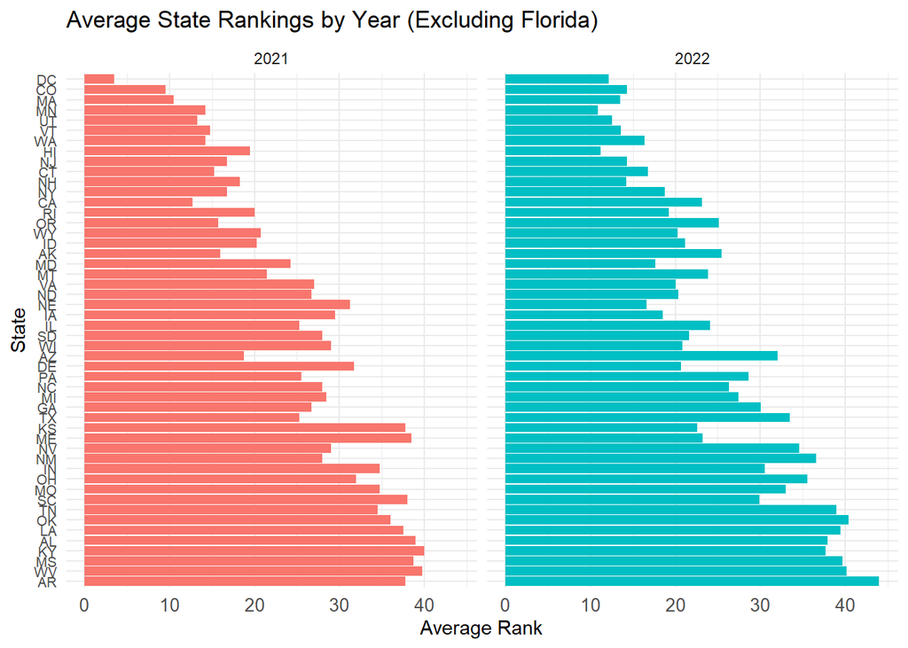

```r
library(ggplot2)
library(dplyr)

ggplot(filtered_state_ranks, aes(x = reorder(StateAbbr, -Average_State_Rank), y = Average_State_Rank)) +
  geom_bar(stat = "identity", aes(fill = as.factor(Year)), show.legend = FALSE) +
  coord_flip() +
  facet_wrap(~ Year) + # Separate panels for 2021 and 2022
  labs(
    title = "Average State Rankings by Year (Excluding Florida)",
    x = "State",
    y = "Average Rank"
  ) +
  theme_minimal() +
  theme(
    axis.text.y = element_text(size = 8),
    axis.text.x = element_text(size = 10)
  )
```

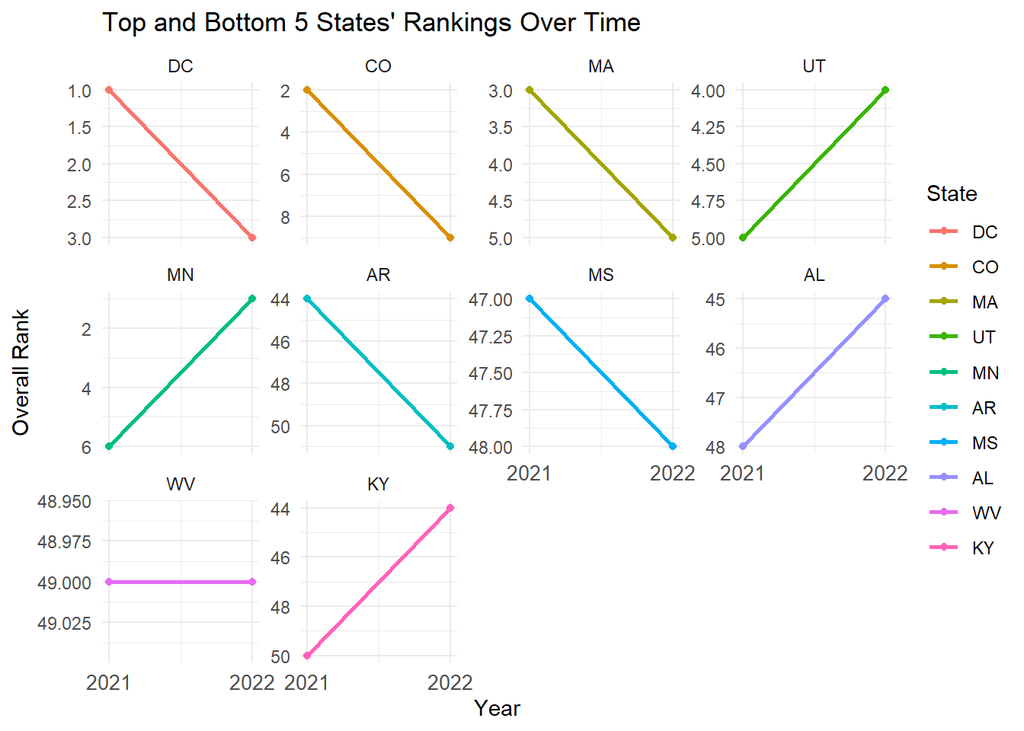

```r
# Filter for Top 5 and Bottom 5 states
top_bottom_states <- state_yearly_ranks %>%
  group_by(StateAbbr) %>%
  summarise(Avg_Rank = mean(Overall_Rank)) %>%
  arrange(Avg_Rank) %>%
  filter(row_number() <= 5 | row_number() > (n() - 5))

# Join back to state_yearly_ranks
filtered_ranks <- state_yearly_ranks %>%
  filter(StateAbbr %in% top_bottom_states$StateAbbr)

# Plot
ggplot(filtered_ranks, aes(x = Year, y = Overall_Rank, group = StateAbbr, color = StateAbbr)) +
  geom_line(size = 1) +
  geom_point() +
  scale_x_continuous(breaks = c(2021, 2022), labels = c("2021", "2022")) + # Only show 2021 and 2022
  scale_y_reverse() + # Reverse y-axis so rank 1 is at the top
  facet_wrap(~ StateAbbr, scales = "free_y") +
  labs(
    title = "Top and Bottom 5 States' Rankings Over Time",
    x = "Year",
    y = "Overall Rank",
    color = "State"
  ) +
  theme_minimal() +
  theme(
    axis.text.x = element_text(size = 10) # Adjust x-axis text size
  )
```

Note: Of the top and bottom states they seem to be consistent with the number of states that increase vs decrease. I am starting to notice that MS, AL, WV and KY are consistently in the bottom of health outcomes.

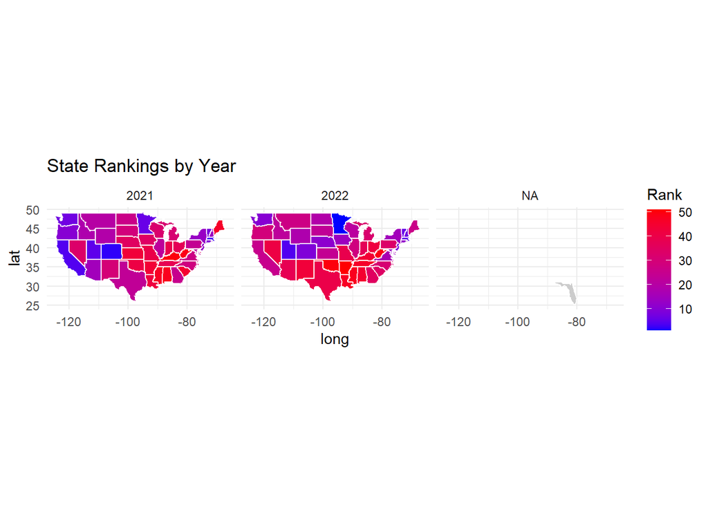

```r
library(ggplot2)
library(dplyr)
library(maps)
# Get map data for US states
us_states <- map_data("state") # Fetches state boundary data
us_states$region <- tolower(us_states$region)

# Prepare the filtered state ranks data
filtered_state_ranks_clean <- filtered_state_ranks %>%
  filter(!is.na(Year)) %>%  # Remove rows where Year is NA
  mutate(region = tolower(state.name[match(StateAbbr, state.abb)])) %>%
  filter(!is.na(region))  # Remove rows where region is NA

# Merge filtered state ranks with map data
map_data_ranks <- us_states %>%
  left_join(filtered_state_ranks_clean, by = "region")
# Plot the U.S. map with state rankings
ggplot(map_data_ranks, aes(x = long, y = lat, group = group, fill = Overall_Rank)) +
  geom_polygon(color = "white", size = 0.4) + # Adds borders around states
  scale_fill_gradient(low = "blue", high = "red", na.value = "grey80") + # Color scale
  coord_fixed(1.3) + # Ensures aspect ratio of the map
  facet_wrap(~ Year) + # Creates separate maps for each year
  labs(
    title = "State Rankings by Year",
    fill = "Rank"
  ) +
  theme_minimal()
```

Note: Florida excluded from dataset appears in NA. I’m also realizing that Hawaii and Alaska are not on the map. A negative health trend in the midwest to south seems to be appearing, with better health on the coasts and north.

**Data Manipulation**

```r
# Summarize State_Rank for each Year, StateAbbr, and Measure
state_ranks_by_measure <- data_frame %>%
  group_by(Year, StateAbbr, MeasureId) %>%
  summarise(
    State_Rank = mean(State_Rank, na.rm = TRUE) # Take average rank in case of duplicates
  ) %>%
  ungroup()
# View the new data frame
head(state_ranks_by_measure)
```

```
## # A tibble: 6 × 4
##    Year StateAbbr MeasureId  State_Rank
##   <dbl> <chr>     <chr>           <dbl>
## 1  2021 AK        BPHIGH              8
## 2  2021 AK        BPMED               2
## 3  2021 AK        CHOLSCREEN         49
## 4  2021 AK        HIGHCHOL            5
## 5  2021 AL        BPHIGH             48
## 6  2021 AL        BPMED              47
```

**Data Manipulation - Making sure state abbreviation shows up next to result**

```r
# Add lowercase state names for merging
state_ranks_by_measure$region <- tolower(state.name[match(state_ranks_by_measure$StateAbbr, state.abb)])
```

**Data Manipulation - Matching map data with ranks from my dataset**

```r
# Get US states map data
us_states <- map_data("state")

# Merge map data with rankings
map_data_ranks <- us_states %>%
  left_join(state_ranks_by_measure, by = "region")
# Confirm that all required columns exist
head(map_data_ranks)
```

```
##        long      lat group order  region subregion Year StateAbbr  MeasureId
## 1 -87.46201 30.38968     1     1 alabama      <NA> 2021        AL     BPHIGH
## 2 -87.46201 30.38968     1     1 alabama      <NA> 2021        AL      BPMED
## 3 -87.46201 30.38968     1     1 alabama      <NA> 2021        AL CHOLSCREEN
## 4 -87.46201 30.38968     1     1 alabama      <NA> 2021        AL   HIGHCHOL
## 5 -87.46201 30.38968     1     1 alabama      <NA> 2022        AL    ACCESS2
## 6 -87.46201 30.38968     1     1 alabama      <NA> 2022        AL  ARTHRITIS
##   State_Rank
## 1         48
## 2         47
## 3         15
## 4         46
## 5         39
## 6         50
```

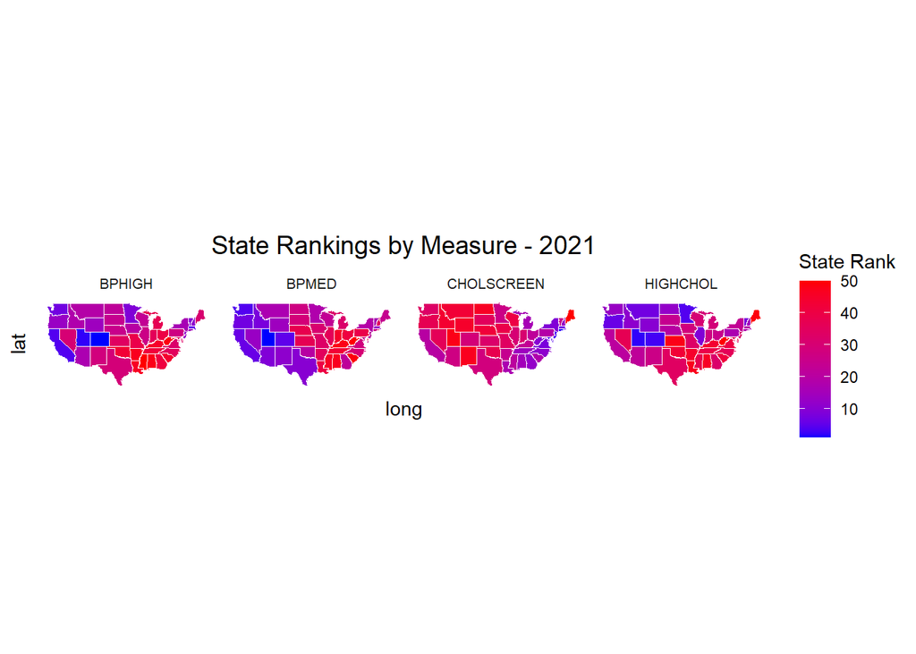

```r
# Filter data for 2021
map_data_ranks_2021 <- map_data_ranks %>%
  filter(Year == 2021)

# Plot grid of U.S. maps for 2021
ggplot(map_data_ranks_2021, aes(x = long, y = lat, group = group, fill = State_Rank)) +
  geom_polygon(color = "white", size = 0.2) + # State borders
  scale_fill_gradient(low = "blue", high = "red", na.value = "grey80") + # Blue = better, red = worse
  coord_fixed(1.3) + # Fix aspect ratio
  facet_wrap(~ MeasureId, ncol = 4) + # Arrange maps in a grid with 4 columns
  labs(
    title = "State Rankings by Measure - 2021",
    fill = "State Rank"
  ) +
  theme_minimal() +
  theme(
    axis.text = element_blank(),
    axis.ticks = element_blank(),
    panel.grid = element_blank(),
    strip.text = element_text(size = 8), # Adjust facet label size for readability
    plot.title = element_text(size = 14, hjust = 0.5) # Center and enlarge the title
  )
```

Note: I think I broke this map when trying to separate the year 2021 and 2022

[figure not shown]

```r
# Filter data for 2022
map_data_ranks_2022 <- map_data_ranks %>%
  filter(Year == 2022)

# Plot grid of U.S. maps for 2022
ggplot(map_data_ranks_2022, aes(x = long, y = lat, group = group, fill = State_Rank)) +
  geom_polygon(color = "white", size = 0.2) + # State borders
  scale_fill_gradient(low = "blue", high = "red", na.value = "grey80") + # Blue = better, red = worse
  coord_fixed(1.3) + # Fix aspect ratio
  facet_wrap(~ MeasureId, ncol = 4) + # Arrange maps in a grid with 4 columns
  labs(
    title = "State Rankings by Measure - 2022",
    fill = "State Rank"
  ) +
  theme_minimal() +
  theme(
    axis.text = element_blank(),
    axis.ticks = element_blank(),
    panel.grid = element_blank(),
    strip.text = element_text(size = 8), # Adjust facet label size for readability
    plot.title = element_text(size = 14, hjust = 0.5) # Center and enlarge the title
  )
```

```r
state_measure_diff <- data_frame %>%
  select(Year, StateAbbr, MeasureId, State_National_Avg_Diff, Category_Type) %>%
  distinct() # Remove duplicates, if any


print(head(state_measure_diff))
```

```
## # A tibble: 6 × 5
##    Year StateAbbr MeasureId  State_National_Avg_Diff Category_Type
##   <dbl> <chr>     <chr>                        <dbl> <chr>
## 1  2022 VA        HEARING                     -0.759 Negative
## 2  2022 VA        OBESITY                      1.26  Negative
## 3  2022 VA        STROKE                      -0.147 Negative
## 4  2022 VA        DEPRESSION                   0.600 Negative
## 5  2022 WA        DEPRESSION                   3.64  Negative
## 6  2022 WA        DISABILITY                  -3.53  Negative
```

```r
us_states <- map_data("state")

# Add 'region' column for merging
state_measure_diff$region <- tolower(state.name[match(state_measure_diff$StateAbbr, state.abb)])

# Merge map data with state-level differences
map_data_states <- us_states %>%
  left_join(state_measure_diff, by = "region")
# Split data for positive and negative Category_Type
positive_data <- map_data_states %>% filter(Category_Type == "Positive")
negative_data <- map_data_states %>% filter(Category_Type == "Negative")
```

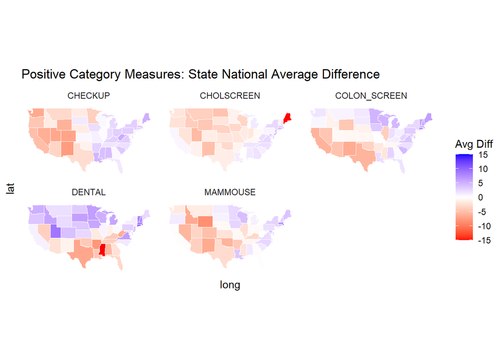

```r
ggplot(positive_data, aes(x = long, y = lat, group = group, fill = State_National_Avg_Diff)) +
  geom_polygon(color = "white", size = 0.2) +
  scale_fill_gradient2(
    low = "red", mid = "white", high = "blue", midpoint = 0,
    limits = c(-15, 15), oob = scales::squish
  ) +
  coord_fixed(1.3) +
  facet_wrap(~ MeasureId, ncol = 3) +
  labs(
    title = "Positive Category Measures: State National Average Difference",
    fill = "Avg Diff"
  ) +
  theme_minimal() +
  theme(
    axis.text = element_blank(),
    axis.ticks = element_blank(),
    panel.grid = element_blank()
  )
```

Note: It seems like checkups might only need to occur when cronic conditions are present indicating worse health conditions,

This interactive graph is meant to show how states compare on different “Measures” because my previous graphs did a bad job.

```
install.packages("shiny")
library(shiny)
library(ggplot2)
library(dplyr)

# UI
ui <- fluidPage(
  titlePanel("Interactive State Ranking Map"),
  sidebarLayout(
    sidebarPanel(
      selectInput("measure_id", "Select Measure ID:",
                  choices = unique(map_data_states$MeasureId))
    ),
    mainPanel(
      plotOutput("state_map")
    )
  )
)

# Server
server <- function(input, output) {

  output$state_map <- renderPlot({
    # Filter data based on selected MeasureId
    filtered_data <- map_data_states %>% filter(MeasureId == input$measure_id)

    # Generate the map
    ggplot(filtered_data, aes(x = long, y = lat, group = group, fill = State_National_Avg_Diff)) +
      geom_polygon(color = "white", size = 0.2) +
      scale_fill_gradient2(
        low = "blue", mid = "white", high = "red", midpoint = 0,
        limits = c(-15, 15), oob = scales::squish
      ) +
      coord_fixed(1.3) +
      labs(
        title = paste("State National Average Difference for", input$measure_id),
        fill = "Avg Diff"
      ) +
      theme_minimal() +
      theme(
        axis.text = element_blank(),
        axis.ticks = element_blank(),
        panel.grid = element_blank()
      )
  })
}

# Run the Shiny App
shinyApp(ui = ui, server = server)
```

Couldn’t get the Shiny app to link here well.

Data Exploration: Finding the best and worst counties compared to national average

```r
library(dplyr)

# Summarize average county rank for all measures
county_health_ranks <- data_frame %>%
  group_by(StateAbbr, CountyName) %>%
  summarise(
    Avg_County_Health = mean(County_National_Avg_Diff, na.rm = TRUE) # Average difference
  ) %>%
  ungroup() %>%
  arrange(Avg_County_Health) # Sort counties for ranking
# Identify the top 10 and bottom 10 counties
top_10_counties <- county_health_ranks %>% top_n(-10, Avg_County_Health)  # Best counties
bottom_10_counties <- county_health_ranks %>% top_n(10, Avg_County_Health) # Worst counties

# Combine the two groups for visualization
top_bottom_counties <- bind_rows(
  top_10_counties %>% mutate(Category = "Best Counties"),
  bottom_10_counties %>% mutate(Category = "Worst Counties")
)

# View the results
print(top_bottom_counties)
```

```
## # A tibble: 20 × 4
##    StateAbbr CountyName Avg_County_Health Category
##    <chr>     <chr>                  <dbl> <chr>
##  1 WY        Teton                  -4.33 Best Counties
##  2 MT        Gallatin               -4.19 Best Counties
##  3 UT        Utah                   -4.17 Best Counties
##  4 CO        Boulder                -4.01 Best Counties
##  5 UT        Summit                 -3.98 Best Counties
##  6 VA        Arlington              -3.93 Best Counties
##  7 CO        Summit                 -3.93 Best Counties
##  8 NM        Los Alamos             -3.92 Best Counties
##  9 CO        Douglas                -3.89 Best Counties
## 10 CO        Broomfield             -3.85 Best Counties
## 11 TX        Dimmit                  6.66 Worst Counties
## 12 GA        Macon                   6.76 Worst Counties
## 13 AL        Lowndes                 6.90 Worst Counties
## 14 LA        Tensas                  7.03 Worst Counties
## 15 AL        Bullock                 7.06 Worst Counties
## 16 AL        Wilcox                  7.28 Worst Counties
## 17 WV        McDowell                7.33 Worst Counties
## 18 KY        Wolfe                   7.36 Worst Counties
## 19 TX        Kenedy                  7.85 Worst Counties
## 20 AL        Greene                  7.89 Worst Counties
```

[figure not shown]

```r
# Add a new column combining CountyName and StateAbbr
top_bottom_counties <- top_bottom_counties %>%
  mutate(County_State = paste0(CountyName, " (", StateAbbr, ")")) # Format: "County (State)"

# Plot the bar chart with the updated y-axis
ggplot(top_bottom_counties, aes(x = reorder(County_State, Avg_County_Health), y = Avg_County_Health, fill = Category)) +
  geom_col() +
  coord_flip() +
  labs(
    title = "Top 10 Best and Worst Counties for Health",
    x = "County (State)",
    y = "Poor outcome Health Score (County_State_Avg_Diff)",
    fill = "Category"
  ) +
  theme_minimal() +
  theme(
    axis.text.y = element_text(size = 8),
    legend.position = "top"  # Optional: Move legend to the top for better layout
  )
```

NOte: Changed X axis title to be less confusing, from “Health score” to “Poor outcome health score” These states appear inline with the states that have negative trends in previous graphs.

This graph is to show counties on a state level and how they compare to other counties within a state.

```
install.packages(c("shiny", "ggplot2", "dplyr", "sf", "tigris", "leaflet"))

library(shiny)
library(ggplot2)
library(dplyr)
library(leaflet)
library(sf)
library(tigris)

# Load or simulate your dataset
# Assume data_frame includes columns: Year, StateAbbr, CountyName, Measure, County_State_Avg_Diff, County_National_Avg_Diff
State_County_Map <- data_frame %>%
  select(Year, StateAbbr, CountyName, Measure, County_State_Avg_Diff, County_National_Avg_Diff) %>%
  filter(!is.na(CountyName))

# Load U.S. county shapefile data
options(tigris_use_cache = TRUE)
us_counties <- tigris::counties(cb = TRUE, resolution = "20m", year = 2020)

# Define UI
ui <- fluidPage(
  titlePanel("Interactive County-Level Health Map"),
  sidebarLayout(
    sidebarPanel(
      selectInput("state", "Select State:", choices = unique(State_County_Map$StateAbbr)),
      selectInput("measure", "Select Measure:", choices = unique(State_County_Map$Measure)),
      radioButtons("comparison", "Compare Against:",
                   choices = c("National Average" = "County_National_Avg_Diff",
                               "State Average" = "County_State_Avg_Diff"),
                   selected = "County_State_Avg_Diff")
    ),
    mainPanel(
      leafletOutput("countyMap")
    )
  )
)

# Define Server
server <- function(input, output) {

  # Filter data based on user input
  filtered_data <- reactive({
    State_County_Map %>%
      filter(StateAbbr == input$state, Measure == input$measure)
  })

  # Merge with shapefile
  county_map_data <- reactive({
    state_counties <- us_counties %>%
      filter(STUSPS == input$state) # Filter counties for selected state

    # Merge geographic data with filtered data
    state_counties <- state_counties %>%
      left_join(filtered_data(), by = c("NAME" = "CountyName"))

    state_counties
  })

  # Render Leaflet Map
  output$countyMap <- renderLeaflet({
    map_data <- county_map_data()

    # Create color palette
    pal <- colorNumeric(palette = "RdBu", domain = map_data[[input$comparison]], na.color = "gray80")

    # Generate Leaflet map
    leaflet(map_data) %>%
      addTiles() %>%
      addPolygons(
        fillColor = ~pal(get(input$comparison)),
        weight = 1,
        color = "white",
        fillOpacity = 0.7,
        smoothFactor = 0.5,
        highlightOptions = highlightOptions(weight = 2, color = "black", bringToFront = TRUE),
        label = ~paste0(NAME, ": ", round(get(input$comparison), 2))
      ) %>%
      addLegend(
        "bottomright",
        pal = pal,
        values = map_data[[input$comparison]],
        title = paste("Comparison:", ifelse(input$comparison == "County_State_Avg_Diff", "State Average", "National Average")),
        opacity = 1
      )
  })
}

# Run the App
shinyApp(ui = ui, server = server)

data_frame
State_County_Map
```

This Matrix is meant to find if there is a relationship between social needs, preventitive care measure, risky health behaviors and the actual health outcomes.

```r
library(dplyr)
library(tidyr)

# Define the selected measures
selected_measures <- c(
  "No leisure-time physical activity among adults",
  "Short sleep duration among adults",
  "Current cigarette smoking among adults",
  "Binge drinking among adults",
  "Obesity among adults",
  "High blood pressure among adults",
  "Frequent mental distress among adults",
  "Frequent physical distress among adults",
  "Chronic obstructive pulmonary disease among adults",
  "Diagnosed diabetes among adults"
)

# Filter, clean, and reshape the data
cor_data <- data_frame %>%
  filter(Measure %in% selected_measures) %>%
  select(StateAbbr, CountyName, Measure, Data_Value) %>%
  mutate(Data_Value = as.numeric(Data_Value)) %>%  # Ensure Data_Value is numeric
  pivot_wider(names_from = Measure, values_from = Data_Value) %>%
  na.omit()  # Remove rows with missing values
# Verify that all selected columns are numeric
cor_data
```

```
## # A tibble: 3,137 × 12
##    StateAbbr CountyName `Obesity among adults` `Diagnosed diabetes among adults`
##    <chr>     <chr>      <list>                 <list>
##  1 VA        Fairfax    <dbl [276]>            <dbl [276]>
##  2 VA        Hampton    <dbl [36]>             <dbl [36]>
##  3 VA        Norfolk    <dbl [77]>             <dbl [77]>
##  4 VA        Suffolk    <dbl [36]>             <dbl [36]>
##  5 WA        Kitsap     <dbl [59]>             <dbl [59]>
##  6 WA        Lincoln    <dbl [4]>              <dbl [4]>
##  7 WA        Pacific    <dbl [11]>             <dbl [11]>
##  8 WA        Pierce     <dbl [193]>            <dbl [193]>
##  9 WA        Skagit     <dbl [41]>             <dbl [41]>
## 10 WA        Skamania   <dbl [5]>              <dbl [5]>
## # ℹ 3,127 more rows
## # ℹ 8 more variables: `No leisure-time physical activity among adults` <list>,
## #   `Current cigarette smoking among adults` <list>,
## #   `Chronic obstructive pulmonary disease among adults` <list>,
## #   `Binge drinking among adults` <list>,
## #   `Short sleep duration among adults` <list>,
## #   `Frequent physical distress among adults` <list>, …
```

```r
library(dplyr)
library(tidyr)

# Fix list-columns by extracting the mean value and converting to numeric
cor_data <- cor_data %>%
  mutate(across(where(is.list), ~ sapply(., function(x) mean(as.numeric(unlist(x)), na.rm = TRUE))))
```

Making sure my data is numeric and not lists

```r
sapply(cor_data, class)
```

```
##                                          StateAbbr
##                                        "character"
##                                         CountyName
##                                        "character"
##                               Obesity among adults
##                                          "numeric"
##                    Diagnosed diabetes among adults
##                                          "numeric"
##     No leisure-time physical activity among adults
##                                          "numeric"
##             Current cigarette smoking among adults
##                                          "numeric"
## Chronic obstructive pulmonary disease among adults
##                                          "numeric"
##                        Binge drinking among adults
##                                          "numeric"
##                  Short sleep duration among adults
##                                          "numeric"
##            Frequent physical distress among adults
##                                          "numeric"
##              Frequent mental distress among adults
##                                          "numeric"
##                   High blood pressure among adults
##                                          "numeric"
```

```r
cor_numeric <- cor_data %>%
  select(-StateAbbr, -CountyName)

# Calculate correlation matrix
cor_matrix <- cor(cor_numeric, use = "pairwise.complete.obs")

# Print the correlation matrix
print(cor_matrix)
```

```
##                                                    Obesity among adults
## Obesity among adults                                          1.0000000
## Diagnosed diabetes among adults                               0.6949367
## No leisure-time physical activity among adults                0.7702035
## Current cigarette smoking among adults                        0.6950285
## Chronic obstructive pulmonary disease among adults            0.5829855
## Binge drinking among adults                                  -0.3687133
## Short sleep duration among adults                             0.5625363
## Frequent physical distress among adults                       0.5801692
## Frequent mental distress among adults                         0.4715821
## High blood pressure among adults                              0.6684535
##                                                    Diagnosed diabetes among adults
## Obesity among adults                                                     0.6949367
## Diagnosed diabetes among adults                                          1.0000000
## No leisure-time physical activity among adults                           0.8754629
## Current cigarette smoking among adults                                   0.6849209
## Chronic obstructive pulmonary disease among adults                       0.7759231
## Binge drinking among adults                                             -0.7054397
## Short sleep duration among adults                                        0.6305957
## Frequent physical distress among adults                                  0.8437000
## Frequent mental distress among adults                                    0.5234454
## High blood pressure among adults                                         0.8754769
##                                                    No leisure-time physical activity among adults
## Obesity among adults                                                                    0.7702035
## Diagnosed diabetes among adults                                                         0.8754629
## No leisure-time physical activity among adults                                          1.0000000
## Current cigarette smoking among adults                                                  0.8010039
## Chronic obstructive pulmonary disease among adults                                      0.7600032
## Binge drinking among adults                                                            -0.5786411
## Short sleep duration among adults                                                       0.6762788
## Frequent physical distress among adults                                                 0.8348472
## Frequent mental distress among adults                                                   0.6209189
## High blood pressure among adults                                                        0.7720076
##                                                    Current cigarette smoking among adults
## Obesity among adults                                                            0.6950285
## Diagnosed diabetes among adults                                                 0.6849209
## No leisure-time physical activity among adults                                  0.8010039
## Current cigarette smoking among adults                                          1.0000000
## Chronic obstructive pulmonary disease among adults                              0.8469174
## Binge drinking among adults                                                    -0.3928453
```

[output cut: 55 more lines]

```
## Short sleep duration among adults                                              0.7390950
## Frequent physical distress among adults                                        0.7322700
## Frequent mental distress among adults                                          1.0000000
## High blood pressure among adults                                               0.3867379
##                                                    High blood pressure among adults
## Obesity among adults                                                      0.6684535
## Diagnosed diabetes among adults                                           0.8754769
## No leisure-time physical activity among adults                            0.7720076
## Current cigarette smoking among adults                                    0.6632327
## Chronic obstructive pulmonary disease among adults                        0.8248777
## Binge drinking among adults                                              -0.7439858
## Short sleep duration among adults                                         0.5252890
## Frequent physical distress among adults                                   0.7483097
## Frequent mental distress among adults                                     0.3867379
## High blood pressure among adults                                          1.0000000
```

Note: There are actually some very interesting results here, most of which are understandable. Obesity among adults is very related to diebetes and not having leisure time, and smoking. COPD is highly related to frequent pain distress in adults and High blood pressure. Some of the most interesting is the binge drinking have a negative correlation with almost all of the negative health outcomes. I was supprised there was a negative correlation between binge drinking and smoking.

Visuilzation of Matrix.

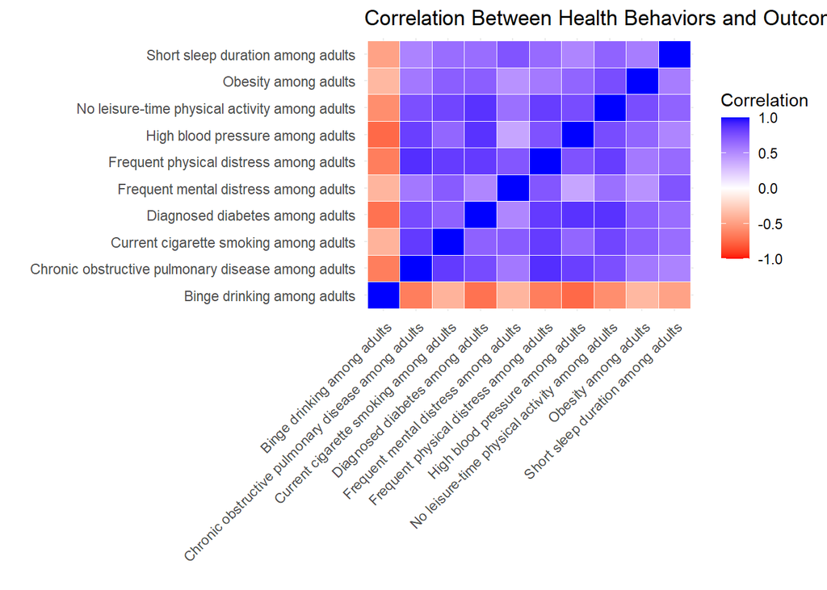

```r
library(ggplot2)
library(tidyr) # For pivot_longer()

# Ensure the correlation matrix contains only numeric values
cor_matrix <- as.data.frame(cor_matrix) # Convert matrix to data frame for tidyr
cor_matrix$Var1 <- rownames(cor_matrix) # Preserve row names for x-axis

# Reshape the correlation matrix into long format
cor_long <- pivot_longer(cor_matrix,
                         cols = -Var1,  # All columns except Var1
                         names_to = "Var2",
                         values_to = "value")

# Plot the heatmap
ggplot(cor_long, aes(Var1, Var2, fill = value)) +
  geom_tile(color = "white") +
  scale_fill_gradient2(low = "red", high = "blue", mid = "white",
                       midpoint = 0, limit = c(-1, 1), space = "Lab",
                       name = "Correlation") +
  labs(
    title = "Correlation Between Health Behaviors and Outcomes",
    x = "", y = ""
  ) +
  theme_minimal() +
  theme(axis.text.x = element_text(angle = 45, hjust = 1))
```

Conclusion: Health trends almost seem to be regional in the United states. The south was fairing worse in 2021 and 2022, but new england, the west coast and the upper midwest seem to be healthier areas to be. This also might be related to having better access to health insurance.